# Project Overview

This project has two parts that demonstrate the importance and value of data visualization techniques in the data analysis process. In the first part, you will use Python visualization libraries to systematically explore a selected dataset, starting from plots of single variables and building up to plots of multiple variables. In the second part, you will produce a short presentation that illustrates interesting properties, trends, and relationships that you discovered in your selected dataset. The primary method of conveying your findings will be through transforming your exploratory visualizations from the first part into polished, explanatory visualizations.

- Introduction
- Part I - Data Wrangling and Data Exploration
- Part II - Explanatory Data Analysis
- Part III - Conclusions

## Why this project?

Data visualization is an important skill that is used in many parts of the data analysis process.

**Exploratory** data visualization generally occurs during and after the data wrangling process, and is the main method that you will use to understand the patterns and relationships present in your data. This understanding will help you approach any statistical analyses and will help you build conclusions and findings. This process might also illuminate additional data cleaning tasks to be performed.

**Explanatory** data visualization techniques are used after generating your findings, and are used to help communicate your results to others. Understanding design considerations will make sure that your message is clear and effective. In addition to being a good producer of visualizations, going through this project will also help you be a good consumer of visualizations that are presented to you by others.

For this project I choose to analyse the results of the OECD **Programme for International Student Assessment (PISA)** in 2012.

From OECD website: *PISA is an international study that was launched by the OECD in 1997, first administered in 2000 and now covers over 80 countries. Every 3 years the PISA survey provides comparative data on 15-year-olds’ performance in reading, mathematics, and science. In addition, each cycle explores a distinct “innovative domain” such as Collaborative Problem Solving (PISA 2015) and Global Competence (PISA 2018). The results have informed education policy discussions at the national and global level since its inception.*  
https://www.oecd.org/pisa/aboutpisa/pisa-based-test-for-schools-faq.htm

**The PISA goals are:**

- Empower school leaders and teachers by providing them with evidence-based analysis of their students’ performance.
- Measure students’ knowledge, skills and competencies that will equip them for success in education and the world of work.
- Provide valuable information on the learning climate within a school, students’ socioeconomic background and motivation for learning.
- Help schools measure a wider range of 21st century skills beyond maths, reading and science.
- Provide opportunities for global peer-learning among teachers and school leaders.

**Based on the objectives of the PISA, using the data, the following questions can be answered:**

1. What is students’ performance at schools in different countries (including whether country is a OECD member).
2. What are the characteristics of students participated in PICA 2012:
   - gender,
   - age,
   - whether a student passed the test in the country of birth or not,
   - international grade and grade compared to modal grade in country.
3. What's a relationship between students performance and highest parental education measured in years as well as mother's and father's highest schooling?
4. Whether there exist a correlation between family wealth (measured in the number of telephones, computers, etc.) and students performance?
5. How do student possessions such as own room and desk, etc. affect his/her performance?
6. Last but not least, whether total time learning and out of school lessons on math, science, and reading affect student performance?

```python
# Import libraries

import os
import pandas as pd
import numpy as np
import matplotlib.pyplot as plt
import seaborn as sns

%matplotlib inline

pd.set_option('display.max_columns', 700)
```

```python
FOLDER = 'C:/Sasha/udacity/Data Analyst Nanodegree Program/5. Data Visualization/8. Communicate Data Findings'

FILE_NAME = 'pisa2012.csv'
DICT_NAME = 'pisadict2012.csv'

file_path = os.path.join(FOLDER, FILE_NAME)
dict_path = os.path.join(FOLDER, DICT_NAME)
```

```python
DTYPES = {'SCHOOLID': 'str', 'STIDSTD': 'str'}
```

```python
# Load in data

df = pd.read_csv(file_path, dtype=DTYPES, encoding='ISO-8859-1')
df.head(2)
```

|  | Unnamed: 0 | CNT | SUBNATIO | STRATUM | OECD | NC | SCHOOLID | STIDSTD | ST01Q01 | ST02Q01 | ST03Q01 | ST03Q02 | ST04Q01 | ST05Q01 | ST06Q01 | ST07Q01 | ST07Q02 | ST07Q03 | ST08Q01 | ST09Q01 | ST115Q01 | ST11Q01 | ST11Q02 | ST11Q03 | ST11Q04 | ST11Q05 | ST11Q06 | ST13Q01 | ST14Q01 | … |
| --- | --- | --- | --- | --- | --- | --- | --- | --- | --- | --- | --- | --- | --- | --- | --- | --- | --- | --- | --- | --- | --- | --- | --- | --- | --- | --- | --- | --- | --- | --- |
| 0 | 1 | Albania | 80000 | ALB0006 | Non-OECD | Albania | 0000001 | 00001 | 10 | 1.0 | 2 | 1996 | Female | No | 6.0 | No, never | No, never | No, never | None | None | 1.0 | Yes | Yes | Yes | Yes | NaN | NaN | <ISCED level 3A> | No | … |
| 1 | 2 | Albania | 80000 | ALB0006 | Non-OECD | Albania | 0000001 | 00002 | 10 | 1.0 | 2 | 1996 | Female | Yes, for more than one year | 7.0 | No, never | No, never | No, never | One or two times | None | 1.0 | Yes | Yes | NaN | Yes | NaN | NaN | <ISCED level 3A> | Yes | … |

Let's first drop unused columns that could slow down our work.

```python
cols_to_keep = ['CNT', 'OECD', 'SCHOOLID', 'STIDSTD', 'AGE', 'ST04Q01', 'ST20Q01', 'ST01Q01', 'GRADE',
                'ST11Q01', 'ST11Q02', 'ST11Q05', 'PARED', 'ST13Q01', 'ST17Q01', 'ST27Q01', 'ST27Q02', 'ST27Q03',
                'ST27Q04', 'ST27Q05', 'ST28Q01', 'ST26Q01', 'ST26Q02', 'ST26Q03', 'ST26Q04', 'ST26Q05', 'ST26Q06',
                'ST55Q01', 'ST55Q02', 'ST55Q03', 'LMINS', 'SMINS', 'MMINS',
                'PV1MATH', 'PV2MATH', 'PV3MATH', 'PV4MATH', 'PV5MATH', 'PV1SCIE', 'PV2SCIE', 'PV3SCIE',
                'PV4SCIE', 'PV5SCIE', 'PV1READ', 'PV2READ', 'PV3READ', 'PV4READ', 'PV5READ']

df = df[cols_to_keep]
df.head(2)
```

|  | CNT | OECD | SCHOOLID | STIDSTD | AGE | ST04Q01 | ST20Q01 | ST01Q01 | GRADE | ST11Q01 | ST11Q02 | ST11Q05 | PARED | ST13Q01 | ST17Q01 | ST27Q01 | ST27Q02 | ST27Q03 | ST27Q04 | ST27Q05 | ST28Q01 | ST26Q01 | ST26Q02 | ST26Q03 | ST26Q04 | ST26Q05 | ST26Q06 | ST55Q01 | ST55Q02 | … |
| --- | --- | --- | --- | --- | --- | --- | --- | --- | --- | --- | --- | --- | --- | --- | --- | --- | --- | --- | --- | --- | --- | --- | --- | --- | --- | --- | --- | --- | --- | --- |
| 0 | Albania | Non-OECD | 0000001 | 00001 | 16.17 | Female | Country of test | 10 | 0.0 | Yes | Yes | NaN | 12.0 | <ISCED level 3A> | <ISCED level 3A> | Two | One | None | None | None | 0-10 books | Yes | No | Yes | No | No | No | NaN | NaN | … |
| 1 | Albania | Non-OECD | 0000001 | 00002 | 16.17 | Female | Country of test | 10 | 0.0 | Yes | Yes | NaN | 16.0 | <ISCED level 3A> | <ISCED level 3A> | Three or more | Three or more | Three or more | Two | Two | 201-500 books | Yes | Yes | Yes | Yes | Yes | Yes | I do not attend <out-of-school time lessons> i... | 2 or more but less than 4 hours a week | … |

We can look at meaning of columns using PISA dictionary data.

```python
# Load in dict data

dict_df = pd.read_csv(dict_path, header=None, names=['value', 'meaning'], skiprows=1, encoding='ISO-8859-1')
dict_df.head()
```

|  | value | meaning |
| --- | --- | --- |
| 0 | CNT | Country code 3-character |
| 1 | SUBNATIO | Adjudicated sub-region code 7-digit code (3-di... |
| 2 | STRATUM | Stratum ID 7-character (cnt + region ID + orig... |
| 3 | OECD | OECD country |
| 4 | NC | National Centre 6-digit Code |

```python
dict_df[dict_df['value'].isin(df.columns)]
```

|  | value | meaning |
| --- | --- | --- |
| 0 | CNT | Country code 3-character |
| 3 | OECD | OECD country |
| 5 | SCHOOLID | School ID 7-digit (region ID + stratum ID + 3-... |
| 6 | STIDSTD | Student ID |
| 7 | ST01Q01 | International Grade |
| 11 | ST04Q01 | Gender |
| 20 | ST11Q01 | At Home - Mother |
| 21 | ST11Q02 | At Home - Father |
| 24 | ST11Q05 | At Home - Grandparents |
| 26 | ST13Q01 | Mother<Highest Schooling> |
| 32 | ST17Q01 | Father<Highest Schooling> |
| 38 | ST20Q01 | Country of Birth International - Self |
| 43 | ST26Q01 | Possessions - desk |
| 44 | ST26Q02 | Possessions - own room |
| 45 | ST26Q03 | Possessions - study place |
| 46 | ST26Q04 | Possessions - computer |
| 47 | ST26Q05 | Possessions - software |
| 48 | ST26Q06 | Possessions - Internet |
| 60 | ST27Q01 | How many - cellular phones |
| 61 | ST27Q02 | How many - televisions |
| 62 | ST27Q03 | How many - computers |
| 63 | ST27Q04 | How many - cars |
| 64 | ST27Q05 | How many - rooms bath or shower |
| 65 | ST28Q01 | How many books at home |
| 136 | ST55Q01 | Out of school lessons - <test lang> |
| 137 | ST55Q02 | Out of school lessons - <maths> |
| 138 | ST55Q03 | Out of school lessons - <science> |
| 410 | AGE | Age of student |
| 411 | GRADE | Grade compared to modal grade in country |
| 460 | LMINS | Learning time (minutes per week) - <test lang... |
| 466 | MMINS | Learning time (minutes per week)- <Mathematics> |
| 472 | PARED | Highest parental education in years |
| 476 | SMINS | Learning time (minutes per week) - <Science> |
| 500 | PV1MATH | Plausible value 1 in mathematics |
| 501 | PV2MATH | Plausible value 2 in mathematics |
| 502 | PV3MATH | Plausible value 3 in mathematics |
| 503 | PV4MATH | Plausible value 4 in mathematics |
| 504 | PV5MATH | Plausible value 5 in mathematics |
| 540 | PV1READ | Plausible value 1 in reading |
| 541 | PV2READ | Plausible value 2 in reading |
| 542 | PV3READ | Plausible value 3 in reading |
| 543 | PV4READ | Plausible value 4 in reading |
| 544 | PV5READ | Plausible value 5 in reading |
| 545 | PV1SCIE | Plausible value 1 in science |
| 546 | PV2SCIE | Plausible value 2 in science |
| 547 | PV3SCIE | Plausible value 3 in science |
| 548 | PV4SCIE | Plausible value 4 in science |
| 549 | PV5SCIE | Plausible value 5 in science |

### General Properties

```python
print('Shape:', df.shape[0], 'rows and', df.shape[1], 'columns')
```

```
Shape: 485490 rows and 48 columns
```

There're 1471 schools with 33806 students in the dataset.

```python
df.SCHOOLID.nunique(), df.STIDSTD.nunique()
```

```
(1471, 33806)
```

Schools and students identifiers were loaded as integers first time, so their types were specified directly when loading data.

```python
df.dtypes
```

```
CNT          object
OECD         object
SCHOOLID     object
STIDSTD      object
AGE         float64
ST04Q01      object
ST20Q01      object
ST01Q01       int64
GRADE       float64
ST11Q01      object
ST11Q02      object
ST11Q05      object
PARED       float64
ST13Q01      object
ST17Q01      object
ST27Q01      object
ST27Q02      object
ST27Q03      object
ST27Q04      object
ST27Q05      object
ST28Q01      object
ST26Q01      object
ST26Q02      object
ST26Q03      object
ST26Q04      object
ST26Q05      object
ST26Q06      object
ST55Q01      object
ST55Q02      object
ST55Q03      object
LMINS       float64
SMINS       float64
MMINS       float64
PV1MATH     float64
PV2MATH     float64
PV3MATH     float64
PV4MATH     float64
PV5MATH     float64
PV1SCIE     float64
PV2SCIE     float64
PV3SCIE     float64
PV4SCIE     float64
PV5SCIE     float64
PV1READ     float64
PV2READ     float64
PV3READ     float64
PV4READ     float64
PV5READ     float64
dtype: object
```

```python
# First, I think, "ST55Q.." clumns should be numeric

df.ST55Q01.unique()
```

```
array([nan,
       'I do not attend <out-of-school time lessons> in this subject',
       'Less than 2 hours a week',
       '4 or more but less than 6 hours a week',
       '2 or more but less than 4 hours a week', '6 or more hours a week'],
      dtype=object)
```

Most rows have some missing values.

```python
df.info()
```

```
<class 'pandas.core.frame.DataFrame'>
RangeIndex: 485490 entries, 0 to 485489
Data columns (total 48 columns):
CNT         485490 non-null object
OECD        485490 non-null object
SCHOOLID    485490 non-null object
STIDSTD     485490 non-null object
AGE         485374 non-null float64
ST04Q01     485490 non-null object
ST20Q01     476363 non-null object
ST01Q01     485490 non-null int64
GRADE       484617 non-null float64
ST11Q01     460559 non-null object
ST11Q02     441036 non-null object
ST11Q05     348180 non-null object
PARED       473091 non-null float64
ST13Q01     457979 non-null object
ST17Q01     443261 non-null object
ST27Q01     477079 non-null object
ST27Q02     476548 non-null object
ST27Q03     473459 non-null object
ST27Q04     472499 non-null object
ST27Q05     469643 non-null object
ST28Q01     473765 non-null object
ST26Q01     473079 non-null object
ST26Q02     469693 non-null object
ST26Q03     472020 non-null object
ST26Q04     473877 non-null object
ST26Q05     463178 non-null object
ST26Q06     473182 non-null object
ST55Q01     307761 non-null object
ST55Q02     308171 non-null object
ST55Q03     306090 non-null object
LMINS       282866 non-null float64
SMINS       270914 non-null float64
MMINS       283303 non-null float64
PV1MATH     485490 non-null float64
PV2MATH     485490 non-null float64
PV3MATH     485490 non-null float64
PV4MATH     485490 non-null float64
PV5MATH     485490 non-null float64
PV1SCIE     485490 non-null float64
PV2SCIE     485490 non-null float64
PV3SCIE     485490 non-null float64
PV4SCIE     485490 non-null float64
PV5SCIE     485490 non-null float64
PV1READ     485490 non-null float64
PV2READ     485490 non-null float64
PV3READ     485490 non-null float64
PV4READ     485490 non-null float64
PV5READ     485490 non-null float64
dtypes: float64(21), int64(1), object(26)
memory usage: 177.8+ MB
```

```python
# Check missing data

df_missing = df.isnull().sum().sort_values(ascending=False)
df_missing[df_missing > 0] / df.shape[0]
```

```
SMINS      0.441978
LMINS      0.417360
MMINS      0.416460
ST55Q03    0.369524
ST55Q01    0.366082
ST55Q02    0.365237
ST11Q05    0.282828
ST11Q02    0.091565
ST17Q01    0.086982
ST13Q01    0.056666
ST11Q01    0.051352
ST26Q05    0.045958
ST27Q05    0.032641
ST26Q02    0.032538
ST26Q03    0.027745
ST27Q04    0.026759
ST26Q01    0.025564
PARED      0.025539
ST26Q06    0.025352
ST27Q03    0.024781
ST28Q01    0.024151
ST26Q04    0.023920
ST20Q01    0.018800
ST27Q02    0.018419
ST27Q01    0.017325
GRADE      0.001798
AGE        0.000239
dtype: float64
```

```python
df[['SMINS', 'LMINS', 'MMINS']].head(10)
```

|  | SMINS | LMINS | MMINS |
| --- | --- | --- | --- |
| 0 | NaN | NaN | NaN |
| 1 | 90.0 | 315.0 | 270.0 |
| 2 | NaN | 300.0 | NaN |
| 3 | 90.0 | 135.0 | 135.0 |
| 4 | NaN | NaN | NaN |
| 5 | NaN | NaN | NaN |
| 6 | 90.0 | 135.0 | 225.0 |
| 7 | NaN | NaN | NaN |
| 8 | NaN | NaN | NaN |
| 9 | 270.0 | 240.0 | 90.0 |

Finally, it's also more than a quater missig values in ST11Q05 column (At Home - Grandparents). He we can asume, NaN in ST11Q05 could be also considered as missing data.

```python
df.ST11Q05.unique()
```

```
array([nan, 'No', 'Yes'], dtype=object)
```

```python
for column in df_missing.index:
    if column not in ('SMINS', 'LMINS', 'MMINS', 'ST55Q03', 'ST55Q01', 'ST55Q02', 'ST11Q05'):
        df[column].fillna(df[column].mode()[0], inplace=True)


# Check NaN
df_missing = df.isnull().sum().sort_values(ascending=False)
df_missing[df_missing > 0] / df.shape[0]
```

```
SMINS      0.441978
LMINS      0.417360
MMINS      0.416460
ST55Q03    0.369524
ST55Q01    0.366082
ST55Q02    0.365237
ST11Q05    0.282828
dtype: float64
```

```python
# Check duplicated rows

df.duplicated().sum() # => there's no duplicated rows
```

```
0
```

```python
# Summary statistics of numeric columns

df.describe()
```

|  | AGE | ST01Q01 | GRADE | PARED | LMINS | SMINS | MMINS | PV1MATH | PV2MATH | PV3MATH | PV4MATH | PV5MATH | PV1SCIE | PV2SCIE | PV3SCIE | PV4SCIE | PV5SCIE | PV1READ | PV2READ | PV3READ | PV4READ | PV5READ |
| --- | --- | --- | --- | --- | --- | --- | --- | --- | --- | --- | --- | --- | --- | --- | --- | --- | --- | --- | --- | --- | --- | --- |
| count | 485490.000000 | 485490.000000 | 485490.000000 | 485490.000000 | 282866.000000 | 270914.000000 | 283303.000000 | 485490.000000 | 485490.000000 | 485490.000000 | 485490.000000 | 485490.000000 | 485490.000000 | 485490.000000 | 485490.000000 | 485490.00000 | 485490.000000 | 485490.000000 | 485490.000000 | 485490.000000 | 485490.000000 | 485490.000000 |
| mean | 15.784234 | 9.813323 | -0.162671 | 12.969808 | 219.276636 | 211.122460 | 226.007056 | 469.621653 | 469.648358 | 469.648930 | 469.641832 | 469.695396 | 475.769824 | 475.813674 | 475.851549 | 475.78524 | 475.820184 | 472.004640 | 472.068052 | 472.022059 | 471.926562 | 472.013506 |
| std | 0.290203 | 3.734726 | 0.655005 | 3.358615 | 97.997730 | 131.368322 | 97.448421 | 103.265391 | 103.382077 | 103.407631 | 103.392286 | 103.419170 | 101.464426 | 101.514649 | 101.495072 | 101.51220 | 101.566347 | 102.505523 | 102.626198 | 102.640489 | 102.576066 | 102.659989 |
| min | 15.170000 | 7.000000 | -3.000000 | 3.000000 | 0.000000 | 0.000000 | 0.000000 | 19.792800 | 6.473000 | 42.226200 | 24.622200 | 37.085200 | 2.648300 | 2.834800 | 11.879900 | 8.42970 | 17.754600 | 0.083400 | 0.703500 | 0.703500 | 4.134400 | 2.307400 |
| 25% | 15.580000 | 9.000000 | 0.000000 | 12.000000 | 165.000000 | 120.000000 | 180.000000 | 395.318600 | 395.318600 | 395.240700 | 395.396500 | 395.240700 | 404.457300 | 404.457300 | 404.550500 | 404.45730 | 404.457300 | 403.600700 | 403.360100 | 403.360100 | 403.354600 | 403.360100 |
| 50% | 15.750000 | 10.000000 | 0.000000 | 13.000000 | 200.000000 | 180.000000 | 220.000000 | 466.201900 | 466.124000 | 466.201900 | 466.279800 | 466.435600 | 475.699400 | 475.606100 | 475.699400 | 475.97910 | 475.885900 | 475.455000 | 475.535200 | 475.455000 | 475.535200 | 475.535200 |
| 75% | 16.000000 | 10.000000 | 0.000000 | 16.000000 | 250.000000 | 270.000000 | 250.000000 | 541.057800 | 541.447300 | 541.291500 | 541.447300 | 541.447300 | 547.780700 | 547.873900 | 547.967200 | 547.78070 | 547.780700 | 544.502500 | 544.503500 | 544.503500 | 544.502500 | 544.503500 |
| max | 16.330000 | 96.000000 | 3.000000 | 18.000000 | 2400.000000 | 2975.000000 | 3000.000000 | 962.229300 | 957.010400 | 935.745400 | 943.456900 | 907.625800 | 903.338300 | 900.540800 | 867.624000 | 926.55730 | 880.958600 | 904.802600 | 881.239200 | 884.447000 | 881.159000 | 901.608600 |

## Part I - Data Wrangling and Data Exploration

```python
# Check values of object columns , and simplify where possible

cat_cols = df.select_dtypes(include='object').columns
cat_cols = cat_cols.drop(['SCHOOLID', 'STIDSTD', 'CNT'])
print('Number of string columns', cat_cols.shape[0])
cat_cols
```

```
Number of string columns 23
```

```
Index(['OECD', 'ST04Q01', 'ST20Q01', 'ST11Q01', 'ST11Q02', 'ST11Q05',
       'ST13Q01', 'ST17Q01', 'ST27Q01', 'ST27Q02', 'ST27Q03', 'ST27Q04',
       'ST27Q05', 'ST28Q01', 'ST26Q01', 'ST26Q02', 'ST26Q03', 'ST26Q04',
       'ST26Q05', 'ST26Q06', 'ST55Q01', 'ST55Q02', 'ST55Q03'],
      dtype='object')
```

There's a lot of categories in CNT column (countries). Look at them seperately.

```python
for column in cat_cols:
    print(column, df[column].nunique(), df[column].unique())
```

```
OECD 2 ['Non-OECD' 'OECD']
ST04Q01 2 ['Female' 'Male']
ST20Q01 2 ['Country of test' 'Other country']
ST11Q01 2 ['Yes' 'No']
ST11Q02 2 ['Yes' 'No']
ST11Q05 2 [nan 'No' 'Yes']
ST13Q01 5 ['<ISCED level 3A> ' '<ISCED level 3B, 3C> '
 'She did not complete <ISCED level 1> ' '<ISCED level 2> '
 '<ISCED level 1> ']
ST17Q01 5 ['<ISCED level 3A> ' '<ISCED level 3B, 3C> ' '<ISCED level 2> '
 'He did not complete <ISCED level 1> ' '<ISCED level 1> ']
ST27Q01 4 ['Two' 'Three or more' 'One' 'None']
ST27Q02 4 ['One' 'Three or more' 'Two' 'None']
ST27Q03 4 ['None' 'Three or more' 'Two' 'One']
ST27Q04 4 ['None' 'Two' 'One' 'Three or more']
ST27Q05 4 ['None' 'Two' 'One' 'Three or more']
ST28Q01 6 ['0-10 books ' '201-500 books ' 'More than 500 books' '11-25 books '
 '101-200 books ' '26-100 books ']
ST26Q01 2 ['Yes' 'No']
ST26Q02 2 ['No' 'Yes']
ST26Q03 2 ['Yes' 'No']
ST26Q04 2 ['No' 'Yes']
ST26Q05 2 ['No' 'Yes']
ST26Q06 2 ['No' 'Yes']
ST55Q01 5 [nan 'I do not attend <out-of-school time lessons> in this subject'
 'Less than 2 hours a week' '4 or more but less than 6 hours a week'
 '2 or more but less than 4 hours a week' '6 or more hours a week']
ST55Q02 5 [nan '2 or more but less than 4 hours a week'
 'I do not attend <out-of-school time lessons> in this subject'
 'Less than 2 hours a week' '6 or more hours a week'
 '4 or more but less than 6 hours a week']
ST55Q03 5 [nan '2 or more but less than 4 hours a week'
 '4 or more but less than 6 hours a week' 'Less than 2 hours a week'
 'I do not attend <out-of-school time lessons> in this subject'
 '6 or more hours a week']
```

For column "How many properties are at home?" replace "None" and NaN values with zeros.

```python
cols_with_none = 'ST27Q01', 'ST27Q02', 'ST27Q03', 'ST27Q04', 'ST27Q05'
for column in cols_with_none:
    df[column] = df[column].replace(['None', np.nan], 'Zero')
```

```python
print('Number of unique countries', df['CNT'].nunique())
df.CNT.unique()
```

```
Number of unique countries 68
```

```
array(['Albania', 'United Arab Emirates', 'Argentina', 'Australia',
       'Austria', 'Belgium', 'Bulgaria', 'Brazil', 'Canada',
       'Switzerland', 'Chile', 'Colombia', 'Costa Rica', 'Czech Republic',
       'Germany', 'Denmark', 'Spain', 'Estonia', 'Finland', 'France',
       'United Kingdom', 'Greece', 'Hong Kong-China', 'Croatia',
       'Hungary', 'Indonesia', 'Ireland', 'Iceland', 'Israel', 'Italy',
       'Jordan', 'Japan', 'Kazakhstan', 'Korea', 'Liechtenstein',
       'Lithuania', 'Luxembourg', 'Latvia', 'Macao-China', 'Mexico',
       'Montenegro', 'Malaysia', 'Netherlands', 'Norway', 'New Zealand',
       'Peru', 'Poland', 'Portugal', 'Qatar', 'China-Shanghai',
       'Perm(Russian Federation)', 'Florida (USA)', 'Connecticut (USA)',
       'Massachusetts (USA)', 'Romania', 'Russian Federation',
       'Singapore', 'Serbia', 'Slovak Republic', 'Slovenia', 'Sweden',
       'Chinese Taipei', 'Thailand', 'Tunisia', 'Turkey', 'Uruguay',
       'United States of America', 'Vietnam'], dtype=object)
```

Some change could be made:

1. Hong Kong-China -> Hong Kong
2. China-Shanghai -> China
3. Perm(Russian Federation) -> Russian Federation (since Perm is just a city in RF)
4. Florida (USA) -> United States of America
5. Connecticut (USA) -> United States of America
6. Massachusetts (USA) -> United States of America
7. Chinese Taipei -> Taiwan
8. Macao-China -> Macao

```python
# Implement changes in NCT column

df['CNT'] = (df['CNT'].replace('Hong Kong-China', 'Hong Kong')
                        .replace('China-Shanghai', 'China')
                        .replace('Perm(Russian Federation)', 'Russian Federation')
                        .replace('Florida (USA)', 'United States of America')
                        .replace('Connecticut (USA)', 'United States of America')
                        .replace('Connecticut (USA)', 'United States of America')
                        .replace('Massachusetts (USA)', 'United States of America')
                        .replace('Chinese Taipei', 'Taiwan')
                        .replace('Macao-China', 'Macao'))
```

```python
# Check changes

print('Number of unique countries', df['CNT'].nunique())
df['CNT'].unique()
```

```
Number of unique countries 64
```

```
array(['Albania', 'United Arab Emirates', 'Argentina', 'Australia',
       'Austria', 'Belgium', 'Bulgaria', 'Brazil', 'Canada',
       'Switzerland', 'Chile', 'Colombia', 'Costa Rica', 'Czech Republic',
       'Germany', 'Denmark', 'Spain', 'Estonia', 'Finland', 'France',
       'United Kingdom', 'Greece', 'Hong Kong', 'Croatia', 'Hungary',
       'Indonesia', 'Ireland', 'Iceland', 'Israel', 'Italy', 'Jordan',
       'Japan', 'Kazakhstan', 'Korea', 'Liechtenstein', 'Lithuania',
       'Luxembourg', 'Latvia', 'Macao', 'Mexico', 'Montenegro',
       'Malaysia', 'Netherlands', 'Norway', 'New Zealand', 'Peru',
       'Poland', 'Portugal', 'Qatar', 'China', 'Russian Federation',
       'United States of America', 'Romania', 'Singapore', 'Serbia',
       'Slovak Republic', 'Slovenia', 'Sweden', 'Taiwan', 'Thailand',
       'Tunisia', 'Turkey', 'Uruguay', 'Vietnam'], dtype=object)
```

Finally, the independent variables "PV..." - plausible values in math, science, and reading - will be summed and diveded by 5 (number of column of each subject).

```python
df['PV_MATH'] = (df.PV1MATH + df.PV2MATH + df.PV3MATH + df.PV4MATH + df.PV5MATH) / 5
df['PV_SCIE'] = (df.PV1SCIE + df.PV2SCIE + df.PV3SCIE + df.PV4SCIE + df.PV5SCIE) / 5
df['PV_READ'] = (df.PV1READ + df.PV2READ + df.PV3READ + df.PV4READ + df.PV5READ) / 5

df[['PV_MATH', 'PV_SCIE', 'PV_READ']].describe()
```

|  | PV_MATH | PV_SCIE | PV_READ |
| --- | --- | --- | --- |
| count | 485490.000000 | 485490.000000 | 485490.000000 |
| mean | 469.651234 | 475.808094 | 472.006964 |
| std | 100.786610 | 97.998470 | 98.863310 |
| min | 54.767080 | 25.158540 | 6.445400 |
| 25% | 396.019620 | 405.762800 | 405.044200 |
| 50% | 465.734520 | 475.512860 | 475.477980 |
| 75% | 540.123060 | 546.381920 | 542.831195 |
| max | 903.107960 | 857.832900 | 849.359740 |

```python
# Drop initial "PV..." columns

df.drop(['PV1MATH', 'PV2MATH', 'PV3MATH', 'PV4MATH', 'PV5MATH', 'PV1SCIE', 'PV2SCIE', 'PV3SCIE', 'PV4SCIE',
         'PV5SCIE', 'PV1READ', 'PV2READ', 'PV3READ', 'PV4READ', 'PV5READ'], axis=1, inplace=True)
```

## Part II - Explanatory Data Analysis

```python
df.head(3)
```

|  | CNT | OECD | SCHOOLID | STIDSTD | AGE | ST04Q01 | ST20Q01 | ST01Q01 | GRADE | ST11Q01 | ST11Q02 | ST11Q05 | PARED | ST13Q01 | ST17Q01 | ST27Q01 | ST27Q02 | ST27Q03 | ST27Q04 | ST27Q05 | ST28Q01 | ST26Q01 | ST26Q02 | ST26Q03 | ST26Q04 | ST26Q05 | ST26Q06 | ST55Q01 | ST55Q02 | … |
| --- | --- | --- | --- | --- | --- | --- | --- | --- | --- | --- | --- | --- | --- | --- | --- | --- | --- | --- | --- | --- | --- | --- | --- | --- | --- | --- | --- | --- | --- | --- |
| 0 | Albania | Non-OECD | 0000001 | 00001 | 16.17 | Female | Country of test | 10 | 0.0 | Yes | Yes | NaN | 12.0 | <ISCED level 3A> | <ISCED level 3A> | Two | One | Zero | Zero | Zero | 0-10 books | Yes | No | Yes | No | No | No | NaN | NaN | … |
| 1 | Albania | Non-OECD | 0000001 | 00002 | 16.17 | Female | Country of test | 10 | 0.0 | Yes | Yes | NaN | 16.0 | <ISCED level 3A> | <ISCED level 3A> | Three or more | Three or more | Three or more | Two | Two | 201-500 books | Yes | Yes | Yes | Yes | Yes | Yes | I do not attend <out-of-school time lessons> i... | 2 or more but less than 4 hours a week | … |
| 2 | Albania | Non-OECD | 0000001 | 00003 | 15.58 | Female | Country of test | 9 | -1.0 | Yes | Yes | No | 16.0 | <ISCED level 3B, 3C> | <ISCED level 3A> | Three or more | Two | Two | One | Two | More than 500 books | Yes | Yes | Yes | Yes | No | Yes | Less than 2 hours a week | 2 or more but less than 4 hours a week | … |

#### 1. What is students’ performance at schools in different countries (including whether country is a OECD member).

```python
base_color = sns.color_palette()[0]
```

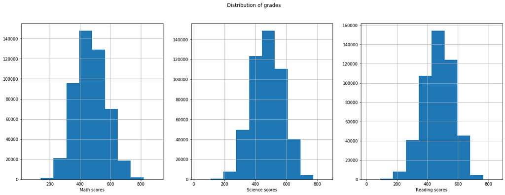

```python
fig, ax = plt.subplots(nrows=1, ncols=3, figsize=(21,7))
df['PV_MATH'].hist(ax=ax[0])
df['PV_SCIE'].hist(ax=ax[1])
df['PV_READ'].hist(ax=ax[2])
ax[0].set_xlabel('Math scores')
ax[1].set_xlabel('Science scores')
ax[2].set_xlabel('Reading scores')
plt.suptitle('Distribution of grades')
plt.show()
```

```python
df['PV_MATH'].mean(), df['PV_SCIE'].mean(), df['PV_READ'].mean()
```

```
(469.65123385442615, 475.80809403002854, 472.0069640898506)
```

If we plot all the grades by subject, then scores in each subject looks normally distributed. Mean scores of science are about 3 points higher than average reading scores. In its turn, avearge reading scores are about 3 poits higher than avearge math scores. So scores in those 3 subjects are very similar.  
So, let's look at their boxplots.

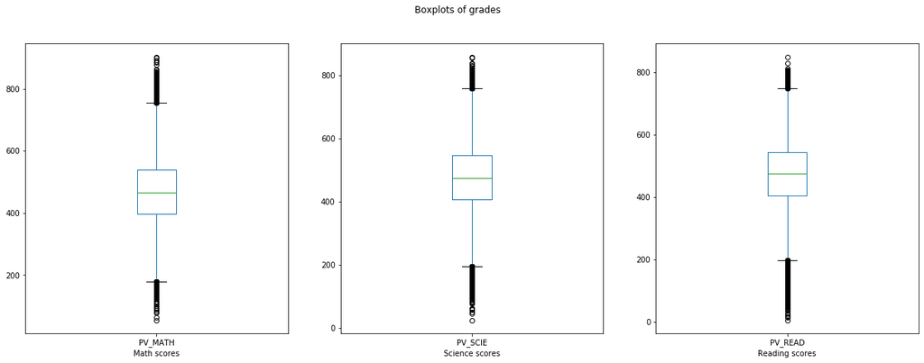

```python
fig, ax = plt.subplots(nrows=1, ncols=3, figsize=(21,7))
df['PV_MATH'].plot(kind='box', ax=ax[0])
df['PV_SCIE'].plot(kind='box', ax=ax[1])
df['PV_READ'].plot(kind='box', ax=ax[2])
ax[0].set_xlabel('Math scores')
ax[1].set_xlabel('Science scores')
ax[2].set_xlabel('Reading scores')
plt.suptitle('Boxplots of grades')
plt.show()
```

In general, there're outliers in every Series of scores. Moreover, math scores have approximately equal tails of outliers, but science and reading scores have outliers with lower scores more, than outliers with higher scores. let's go deepper, and look at students perormance in the context of countries, OECD membership, and other columns.

```python
df_plot1 = df.groupby('CNT').agg({'PV_MATH': 'mean', 'PV_SCIE': 'mean', 'PV_READ': 'mean', 'STIDSTD': 'nunique'})

print('Shape', df_plot1.shape)
df_plot1.head()
```

```
Shape (64, 4)
```

| CNT | PV_MATH | PV_SCIE | PV_READ | STIDSTD |
| --- | --- | --- | --- | --- |
| Albania | 394.878912 | 398.916529 | 396.250245 | 4743 |
| Argentina | 395.635711 | 410.478404 | 403.596060 | 5908 |
| Australia | 493.268939 | 511.638212 | 501.056931 | 14481 |
| Austria | 507.778785 | 508.036810 | 491.485551 | 4755 |
| Belgium | 519.668410 | 510.302595 | 512.281728 | 8597 |

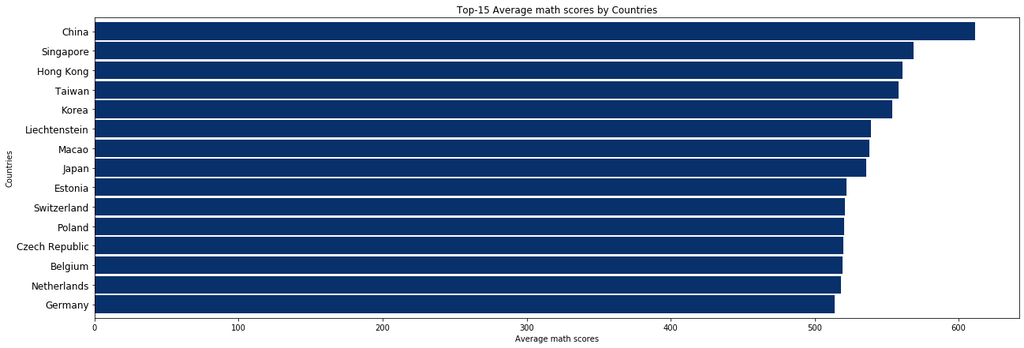

```python
df_plot1[['PV_MATH']].sort_values('PV_MATH').iloc[-15:].plot.barh(figsize=(21,7), width=.9, legend=False,
                                                                  cmap='Blues_r')
plt.yticks(fontsize=12)
plt.xlabel('Average math scores')
plt.ylabel('Countries')
plt.title('Top-15 Average math scores by Countries')
plt.show()
```

```python
df[df.CNT == 'China'].PV_MATH.mean(), df[df.CNT == 'Peru'].PV_MATH.mean()
```

```
(611.4389329882152, 367.8596761126761)
```

Except Liechtenstein which is on the 6th position, on average, students from Asia countries receive the highest scores on math. China, Singapore, Hong Kong, Taiwan, and Korea are in Top-5. Macao and Japan follow immediately behind Liechtenstein.  
Chinese students receive on average 611 points. In comparison, in Peru average math scores are equal 368. This's 1.7 times less than in China.

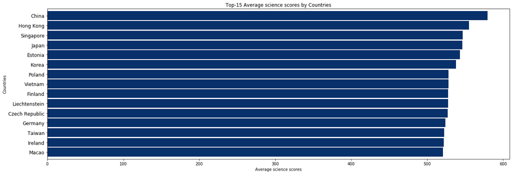

```python
df_plot1[['PV_SCIE']].sort_values('PV_SCIE').iloc[-15:].plot.barh(figsize=(21,7), width=.9, legend=False,
                                                                  cmap='Blues_r')
plt.yticks(fontsize=12)
plt.xlabel('Average science scores')
plt.ylabel('Countries')
plt.title('Top-15 Average science scores by Countries')
plt.show()
```

```python
(df[df.CNT == 'China'].PV_SCIE.mean(), df[df.CNT == 'Hong Kong'].PV_SCIE.mean(),
            df[df.CNT == 'Singapore'].PV_SCIE.mean())
```

```
(579.5565404481328, 554.9864334004274, 546.8229195961078)
```

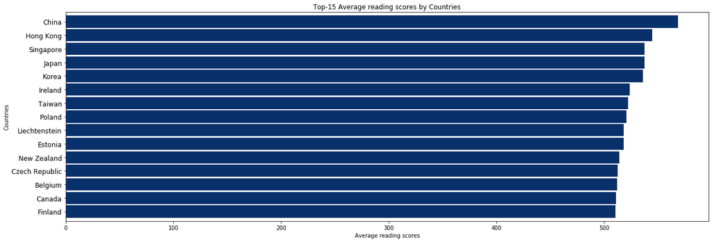

```python
df_plot1[['PV_READ']].sort_values('PV_READ').iloc[-15:].plot.barh(figsize=(21,7), width=.9, legend=False,
                                                                  cmap='Blues_r')
plt.yticks(fontsize=12)
plt.xlabel('Average reading scores')
plt.ylabel('Countries')
plt.title('Top-15 Average reading scores by Countries')
plt.show()
```

```python
df[df.CNT == 'China'].PV_READ.mean()
```

```
568.6292328568668
```

For average reading scores, China, Hong Kong, Singapore, Japan, Korea and Taiwan continue to be the leaders with a maximum average of 569 points for China. This average score is the lowest for China in three subjects, possibly also because English is not a native language for a large population of the country.

```python
df_plot2 = df.groupby('OECD').agg({'PV_MATH': 'mean', 'PV_SCIE': 'mean', 'PV_READ': 'mean', 'STIDSTD': 'nunique'})
print(df_plot2)
```

```
             PV_MATH     PV_SCIE     PV_READ  STIDSTD
OECD
Non-OECD  440.509684  446.101570  442.803610    19204
OECD      488.401237  494.921608  490.796733    33806
```

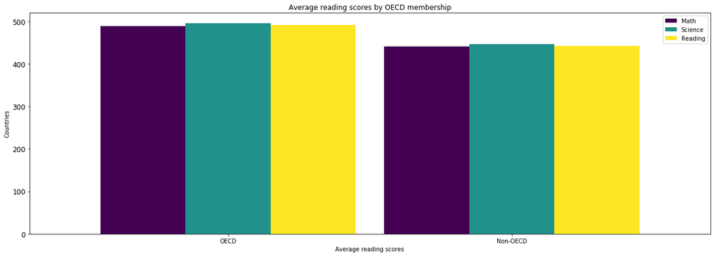

```python
df_plot2[['PV_MATH', 'PV_SCIE', 'PV_READ']].sort_values('PV_READ', ascending=False).plot.bar(
                    figsize=(21,7), width=.9, legend=True, cmap='viridis', rot=0)
plt.legend(['Math', 'Science', 'Reading'])
plt.yticks(fontsize=12)
plt.xlabel('Average reading scores')
plt.ylabel('Countries')
plt.title('Average reading scores by OECD membership')
plt.show()
```

The difference is noticeable in all three subjects at once: average scores in mathematics, science and reading are higher in OSCE countries than in non-OSCE countries. The difference is about 48 points for each subject.

#### 2. What are the characteristics of students participated in PICA 2012:

- gender,
- age,
- whether a student passed the test in the country of birth or not,
- international grade and grade compared to modal grade in country.

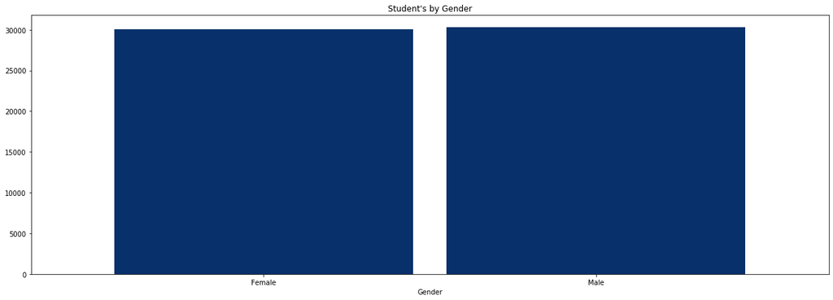

```python
df.groupby('ST04Q01').STIDSTD.nunique().sort_index().plot.bar(figsize=(21,7), width=.9, legend=False,
                                                                  cmap='Blues_r', rot=0)
plt.xlabel('Gender')
plt.title('Student\'s by Gender')
plt.show()
```

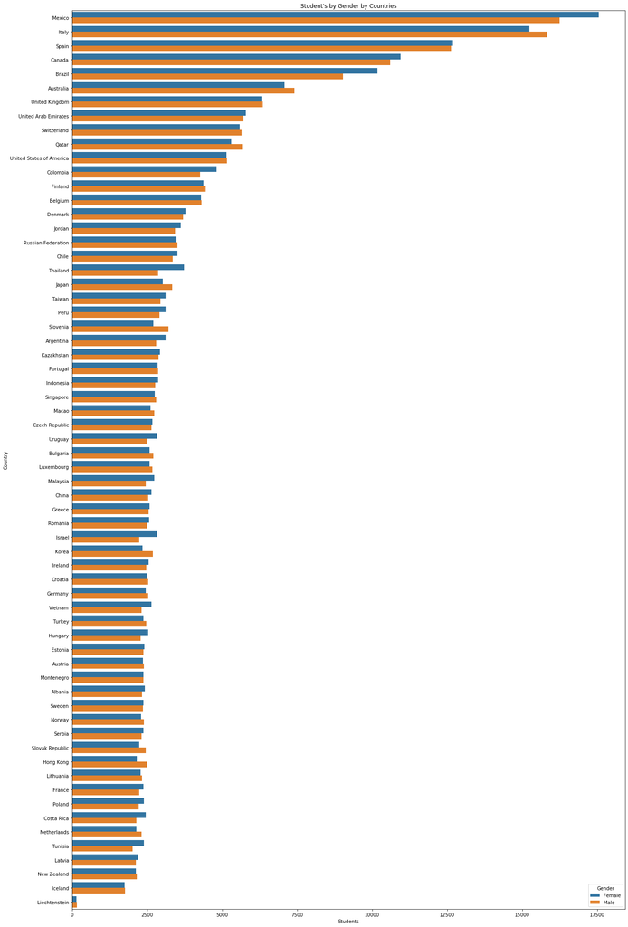

```python
fig, ax = plt.subplots(figsize=(21,35))
df.sort_values(by=['ST04Q01', 'CNT'])
sns.countplot(data=df, y='CNT', hue='ST04Q01', ax=ax, order=df['CNT'].value_counts().index)
ax.legend(title='Gender', loc='best')
plt.xlabel('Students')
plt.ylabel('Country')
plt.title('Student\'s by Gender by Countries')
plt.show()
```

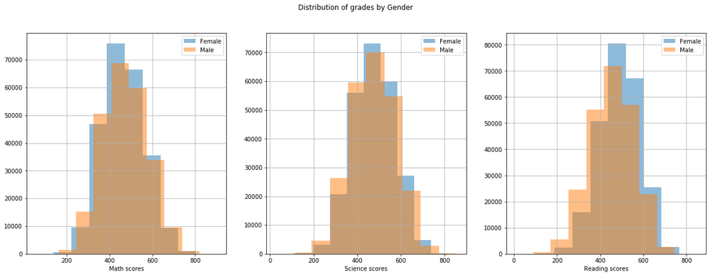

```python
fig, ax = plt.subplots(nrows=1, ncols=3, figsize=(21,7))
df[df.ST04Q01 == 'Female']['PV_MATH'].hist(ax=ax[0], alpha=.5, label='Female')
df[df.ST04Q01 == 'Male']['PV_MATH'].hist(ax=ax[0], alpha=.5, label='Male')
ax[0].set_xlabel('Math scores')
ax[0].legend()

df[df.ST04Q01 == 'Female']['PV_SCIE'].hist(ax=ax[1], alpha=.5, label='Female')
df[df.ST04Q01 == 'Male']['PV_SCIE'].hist(ax=ax[1], alpha=.5, label='Male')
ax[1].set_xlabel('Science scores')
ax[1].legend()

df[df.ST04Q01 == 'Female']['PV_READ'].hist(ax=ax[2], alpha=.5, label='Female')
df[df.ST04Q01 == 'Male']['PV_READ'].hist(ax=ax[2], alpha=.5, label='Male')
ax[2].set_xlabel('Reading scores')
ax[2].legend()

plt.suptitle('Distribution of grades by Gender')
plt.show()
```

Distriution of males and females math and science score are distributed approximately normal. However, there's slight difference of reading scores: female have aslightly higher grades than males.